# MasterClass DataViz

## Analyser les accidents de la route de l'année 2016

> Lors de cette Masterclass, nous allons être chargés par une Compagnie d'Assurance de mener une étude sur les accidents de la route, impliquant ses clients assurés au cours de l'année 2016.

> Dans un but d'analyse et de comparaisons, nous avons accès à des jeux de données publiques concernant les circonstances des accidents de la route avec dommages corporels survenus en France en 2016 , ainsi qu'aux données internes de la compagnie à propos de ses assurés victimes d'accident la même année.

> Le fichier "caracteristiques.csv" contient les principales caractéristiques de chaque accident survenu en France en 2016.

> Le fichier "base_clients.csv" contient des informations sur les clients de la compagnie d'assurance, qui ont été impliqués dans au moins un accident en 2016.

> `Num_Acc` est une variable commune à tous les fichiers, qui identifie chaque accident.

> Une description de toutes les variables des jeux de données est disponible [ici](https://datascientest.fr/train/assets/eval_allianz_3.pdf).

> L'objectif de cette masterclass est d'effectuer une première analyse visuelle des données en notre possession.
- Commençons par charger les packages **pandas**, **numpy**, **matplotlib.pyplot**, et **seaborn**.
- Puis chargeons les jeux de données *'caracteristiques.csv* et *'base_clients.csv'* dans des dataframes nommés respectivement **carac** et **clients**.

```python
import warnings
warnings.filterwarnings("ignore")
## Insérez votre code ici
import pandas as pd
import numpy as np
import matplotlib.pyplot as plt
import seaborn as sns

carac = pd.read_csv("caracteristiques.csv")
clients = pd.read_csv("base_clients.csv")
```

> Nous allons commencer par nous intéresser à l'ensemble des accidents corporels de l'année 2016.
- Affichons les premières lignes de **carac**, puis les informations sur chaque variable.

```python
## Insérez votre code ici
```

```
        Num_Acc  an  mois  jour  hrmn  lum  agg                atm  col  grav  \
0  201600000001  16     2     1  1445    1    2      Temps couvert  3.0     2
1  201600000002  16     3    16  1800    1    2             Normal  6.0     2
2  201600000003  16     7    13  1900    1    1             Normal  6.0     2
3  201600000004  16     8    15  1930    2    2  Temps eblouissant  3.0     1
4  201600000005  16    12    23  1100    1    2             Normal  3.0     2

   com                  adr gps  lat  long  dep
0    5   46, rue Sonneville   M  0.0   0.0   59
1    5  1a rue du cimetière   M  0.0   0.0   59
2   11                  NaN   M  0.0   0.0   59
3  477   52 rue victor hugo   M  0.0   0.0   59
4   11     rue Joliot curie   M  0.0   0.0   59
            Num_Acc       an          mois          jour          hrmn  \
count  5.943200e+04  59432.0  59432.000000  59432.000000  59432.000000
mean   2.016000e+11     16.0      6.763225     15.532626   1373.312710
std    1.715668e+04      0.0      3.435432      8.811624    545.604479
min    2.016000e+11     16.0      1.000000      1.000000      1.000000
25%    2.016000e+11     16.0      4.000000      8.000000    945.000000
50%    2.016000e+11     16.0      7.000000     15.000000   1442.000000
75%    2.016000e+11     16.0     10.000000     23.000000   1810.000000
max    2.016001e+11     16.0     12.000000     31.000000   2359.000000

                lum           agg           col         grav           com  \
count  59432.000000  59432.000000  59430.000000  59432.00000  59432.000000
mean       1.909039      1.644569      4.126283      1.41513    189.693465
std        1.503857      0.478648      1.962217      0.56348    170.001085
min        1.000000      1.000000      1.000000      1.00000      1.000000
25%        1.000000      1.000000      3.000000      1.00000     57.000000
50%        1.000000      2.000000      3.000000      1.00000    118.000000
75%        3.000000      2.000000      6.000000      2.00000    281.000000
max        5.000000      2.000000      7.000000      3.00000    907.000000

                lat          long           dep
count  4.658500e+04  4.658500e+04  59432.000000
mean   4.101576e+06  2.368367e+05     86.476595
std    1.568368e+06  4.428120e+05    164.069681
min    0.000000e+00 -4.760340e+05      1.000000
25%    4.353665e+06  0.000000e+00     33.000000
50%    4.722596e+06  2.321900e+05     67.000000
75%    4.883760e+06  4.021730e+05     84.000000
max    5.106528e+06  6.156877e+06    976.000000
```

```python
## Insérez votre code ici
```

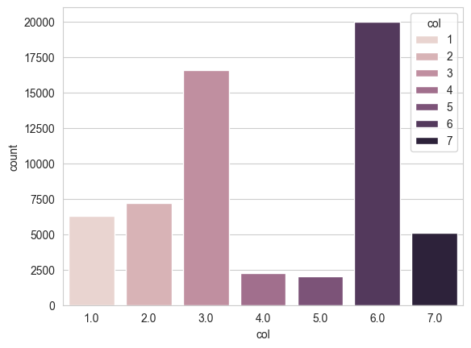

> Il apparaît que les accidents survenus par collison à deux véhicules et par le côté sont les plus fréquents, après 'Autres' dont on ignore la signification.

> Notre DataFrame contient le jour, le mois et l'année (2016) de chaque accident, il est donc possible d'en extraire la date exacte, afin d'afficher un graphique daté chronologique, ou chaque point correspond à un jour de l'année 2016.
- Pour cela, il faut dans un premier temps créer une variable contenant la date complète pour chaque accident.  
  Puis convertir cette variable en `datetime` et compter le nombre d'occurences pour chaque date.
- Pour pouvoir afficher un graphique chronologique, il faut ordonner ces valeurs selon les dates en indices.
- Il suffit ensuite d'utiliser la méthode `plot_date()` de *matplotlib*, pour afficher les index et les valeurs qui correspondent aux nombre d'accident pour chaque jour.

```python
## Insérez votre code ici
```

```
date
2016-06-10    263
2016-11-30    260
2016-10-11    250
2016-08-07    247
2016-11-18    242
             ...
2016-02-21     99
2016-12-31     92
2016-12-25     82
2016-01-17     81
2016-03-28     68
Name: count, Length: 366, dtype: int64
```

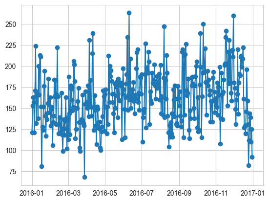

> Le graphique nous montre des pics d'accidents importants pour certains jours, et une tendance globale qui montre que certains mois sont plus propices aux accients que d'autres.
- Vérifions ce constat, en affichant le nombre d'accidents par mois.

```python
## Insérez votre code ici
```

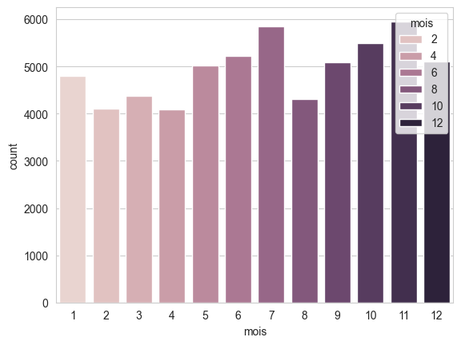

> Les mois de Février, Avril et Août sont les mois avec le moins d'accidents corporels enregistrés. Les mois de Novembre et Juillet sont les mois recensant le plus d'accidents.  
> Qu'en est-il des jours de la semaine?

> La méthode `dt.weekday` permet de déterminer le jour de la semaine à partir d'une date au format `datetime`.
- Comparons le nombre d'accidents pour chaque jour de la semaine au cours de l'année 2016.

```python
## Insérez votre code ici
```

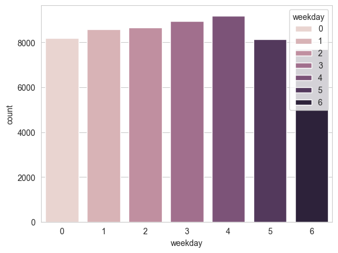

```python
## Insérez votre code ici:
```

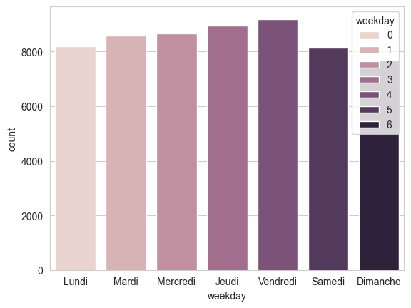

> La variable *`hrmn`* contient l'heure et les minutes de chaque accident.
- Affichons la distribution de cette variable, en choisissant 24 intervalles, et ajouter les heures séparant la journée sur l'axe des abscisses.

```python
## Insérez votre code ici
```

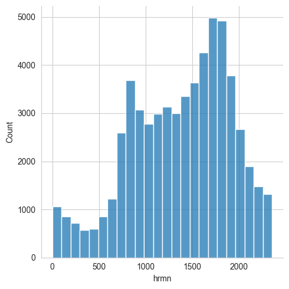

```python
## Insérez votre code ici
```

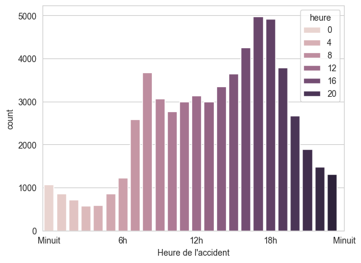

> Il semble y avoir une grande partie des accidents le matin, et dans la soirée entre 17h et 19h. Logique, puisqu'il s'agit des heures de la journée où l'on observe le plus de circulations.

> Y a-t-il des départements plus intéressés par sécurité routière que d'autres?
- Affichons, côtes à côtes, les 10 départements avec le plus d'accidents, et les 10 avec le moins d'accidents en 2016.

```python
## Insérez votre code ici
```

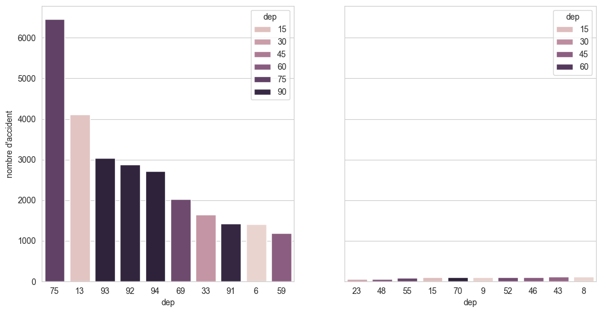

> La majorité des départements avec le plus d'accidents font partie des départements les plus peuplés de France. La réciproque est aussi vrai pour les départements les moins peuplés.

> Les département d'Outre-Mer ne font parte d'aucun des deux classements, il pourrait être intéressant d'observer en moyenne, combien d'accidents corporels touchent ces départements par mois, par rapport aux départements de métropole.
- Affichons l'évolution du nombre d'accidents moyen par mois et par département pour les Dom-Tom et la métropole.

```python
## Insérez votre code ici
```

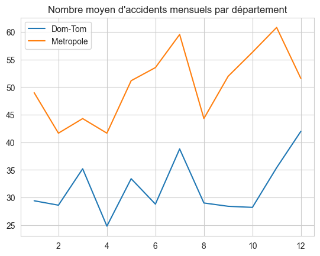

> Regardons à présent, où se situent géographiquement les différents accidents ayant lieu en métropole, selon leurs degrés de gravité.
- Exécutez la cellule suivante pour afficher les coordonnées de chaque accident de métropole.

```python
## Insérez votre code ici
```

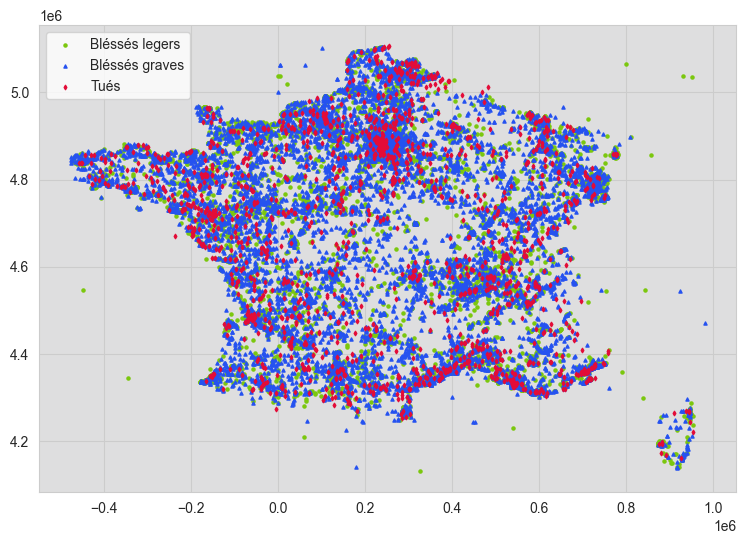

> La variable *`atm`* distingue les conditions athmospériques des accidents survenus, la variable *`grave`* le niveau de gravité maximum de l'accident, et *'col'* le type de collisions.
- Comment les conditions athmosphériques et le type de collision influent sur la gravité de l'accident?

```python
## Insérez votre code ici
```

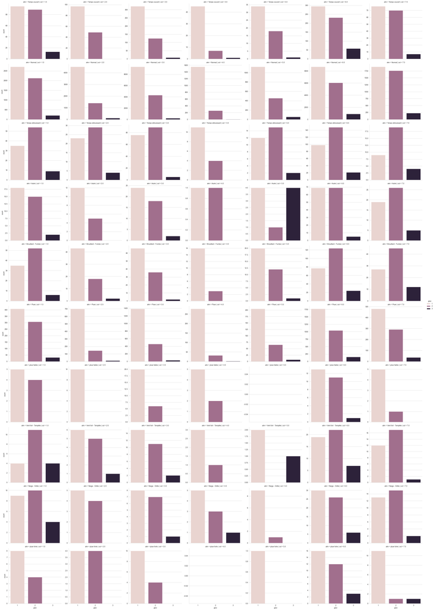

> Nous allons à présent nous intéresser à la base de données clients.
- Affichons un aperçu des premières lignes du Dataframe **clients**.

```python
## Insérez votre code ici
```

|  | ID_Client | Num_Acc | dep_residence | Souscription_Premium+ | cout | annees_permis | age_v | sexe | age |
| --- | --- | --- | --- | --- | --- | --- | --- | --- | --- |
| 0 | ID_00015117 | 201600000009 | 59 | 0 | 1273.071553 | 0 | 7.0 | F | 32.0 |
| 1 | ID_00019488 | 201600000010 | 59 | 0 | 1180.182189 | 0 | 7.0 | H | 25.0 |
| 2 | ID_00011159 | 201600000011 | 59 | 0 | 625.490049 | 9 | 5.0 | H | 43.0 |
| 3 | ID_00019361 | 201600000024 | 59 | 0 | 522.757581 | 9 | 9.0 | F | 60.0 |
| 4 | ID_00016105 | 201600000025 | 59 | 0 | 346.974776 | +10ans | 9.0 | F | 50.0 |

> Quelle part des accidents de la route avec dommages corporels, ceux impliquant les clients de la compagnie d'Assurance représentent-ils?
- Afficher, dans un diagramme circulaire, la part d'accidents impliquant des clients de la compagnie

```python
## Insérez votre code ici
```

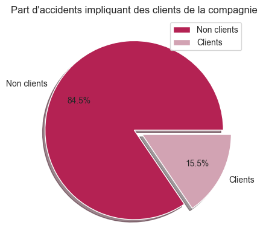

> Quel age ont les clients?
- Affichons la distributions de la variable *`age`*.

```python
## Insérez votre code ici
```

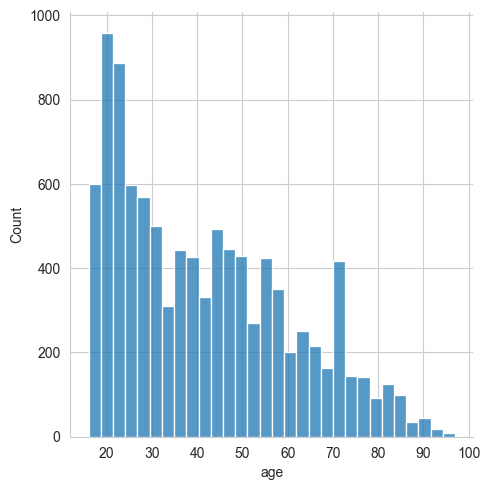

> La moyenne d'âge des clients assurés est d'environ 40 ans. La catégorie des 18-25ans est la plus représentée.  
> Le cout annuelle de l'assurance auto pour les clients dépend-il de l'âge?
- Analysons la relation entre les variables *`age`* et *`cout`*, à l'aide d'un nuage de point et d'une courbe de tendance d'ordre 2.

```python
## Insérez votre code ici
```

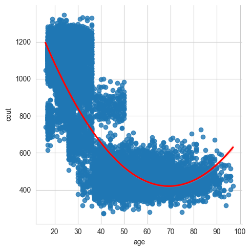

> Le coût de l'assurance semble décroire avec l'âge du client. Cependant, après la cinquantaine, le coût se stabilise et peut parfois être éventuellement élevé même à un âge avancé. Ceci pourrait s'expliquer par d'autres facteurs comme le type de voiture utilisé ou l'âge de cette dernière.
- Parmis les clients assurés, combien ont souscrit à l'offre 'Premium+'? Comparons la part de clients Premium+ chez les hommes et le femmes.

```python
## Insérez votre code ici
```

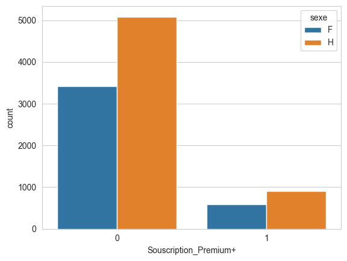

> Les jeunes ou moins jeunes conducteurs sont-ils plus concernés par les accidents impliquant un décès?
- Affichons un graphique représentant la distribution de l'age des clients, en fonction de la gravité de l'accident.

```python
## Insérez votre code ici
```

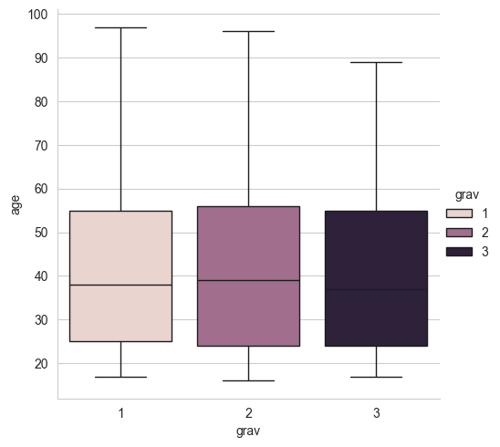

> L'age moyen est moins elevé pour les accidents impliquant un décès, mais de manière trop lègère pour être significative.

> Un nombre d'années de permis élevé présume-t-il d'une meilleure conduite?
- Affichons le nombres d'accidents par degré de gravité, en fonction du nombre d'années de permis.

```python
## Insérez votre code ici
```

[figure not shown]

> Nous sommes arrivés à la fin de cette *MasterClass*, merci de l'avoir suivi. Vous pouvez bien entendu continuer à explorer les données sous différents angles, à vous de jouer !